# Practical Machine Learning Final Project

Rafael Mejia

11 de noviembre de 2018

#Practical Machine Learning - Final Project

##Background Using devices such as Jawbone Up, Nike FuelBand, and Fitbit it is now possible to collect a large amount of data about personal activity relatively inexpensively. These type of devices are part of the quantified self movement – a group of enthusiasts who take measurements about themselves regularly to improve their health, to find patterns in their behavior, or because they are tech geeks. One thing that people regularly do is quantify how much of a particular activity they do, but they rarely quantify how well they do it.

In this project, our goal will be to use data from accelerometers on the belt, forearm, arm, and dumbell of 6 participants. They were asked to perform barbell lifts correctly and incorrectly in 5 different ways. The goal of this project is to predict the manner in which they did the exercise.

The data for this project come from this source: http://groupware.les.inf.puc-rio.br/har. If you use the document you create for this class for any purpose please cite them as they have been very generous in allowing their data to be used for this kind of assignment.

## 1. Load data

```r
#Libraries
library("caret")
```

```r
#Download the data
if(!file.exists("df_training.csv")){download.file("https://d396qusza40orc.cloudfront.net/predmachlearn/pml-training.csv", destfile = "df_training.csv")}

if(!file.exists("df_testing.csv")){download.file("https://d396qusza40orc.cloudfront.net/predmachlearn/pml-testing.csv", destfile = "df_testing.csv")}


#Read the training data and replace empty values by NA
trainingDataSet<- read.csv("df_training.csv", sep=",", header=TRUE, na.strings = c("NA","",'#DIV/0!'))
testingDataSet<- read.csv("df_testing.csv", sep=",", header=TRUE, na.strings = c("NA","",'#DIV/0!'))
dim(trainingDataSet)
```

```
## [1] 19622   160
```

The dataset consist of 19,622 values of 160 variables.

```r
#View testing data dimensions
dim(testingDataSet)
```

```
## [1]  20 160
```

And the testing dataset consist of 20 values of 160 variables.

## 2. Cleaning data

Removing columns with missing values.

```r
trainingDataSet <- trainingDataSet[,(colSums(is.na(trainingDataSet)) == 0)]
dim(trainingDataSet)
```

```
## [1] 19622    60
```

Now, we have a daset with 60 columns (variables).

```r
testingDataSet <- testingDataSet[,(colSums(is.na(testingDataSet)) == 0)]
dim(testingDataSet)
```

```
## [1] 20 60
```

And, we aplly the same column removing to the testing dataset, now with 60 columns.

## 3. Pre-processing data

```r
numericIds <- which(lapply(trainingDataSet, class) %in% "numeric")

preprocessModel <-preProcess(trainingDataSet[,numericIds],method=c('knnImpute', 'center', 'scale'))
pre_trainingDataSet <- predict(preprocessModel, trainingDataSet[,numericIds])
pre_trainingDataSet$classe <- trainingDataSet$classe

pre_testingDataSet <-predict(preprocessModel,testingDataSet[,numericIds])

#This will remove non-zero variables
nzv <- nearZeroVar(pre_trainingDataSet,saveMetrics=TRUE)
pre_trainingDataSet <- pre_trainingDataSet[,nzv$nzv==FALSE]

nzv <- nearZeroVar(pre_testingDataSet,saveMetrics=TRUE)
pre_testingDataSet <- pre_testingDataSet[,nzv$nzv==FALSE]
```

## 4. Validate set

```r
set.seed(12031987)
idsTrain<- createDataPartition(pre_trainingDataSet$classe, p=3/4, list=FALSE)
training<- pre_trainingDataSet[idsTrain, ]
validation <- pre_trainingDataSet[-idsTrain, ]
dim(training) ; dim(validation)
```

```
## [1] 14718    28
```

```
## [1] 4904   28
```

## 5. Training model

Training the model using random forest with cross validatio.

```r
library(randomForest)
modelRF <- train(classe ~., method="rf", data=training, trControl=trainControl(method='cv'), number=5, allowParallel=TRUE, importance=TRUE )
modelRF
```

```
## Random Forest
##
## 14718 samples
##    27 predictor
##     5 classes: 'A', 'B', 'C', 'D', 'E'
##
## No pre-processing
## Resampling: Cross-Validated (10 fold)
## Summary of sample sizes: 13246, 13248, 13247, 13245, 13245, 13246, ...
## Resampling results across tuning parameters:
##
##   mtry  Accuracy   Kappa
##    2    0.9927297  0.9908032
##   14    0.9921869  0.9901172
##   27    0.9891973  0.9863360
##
## Accuracy was used to select the optimal model using the largest value.
## The final value used for the model was mtry = 2.
```

## 6. Model Interpretation

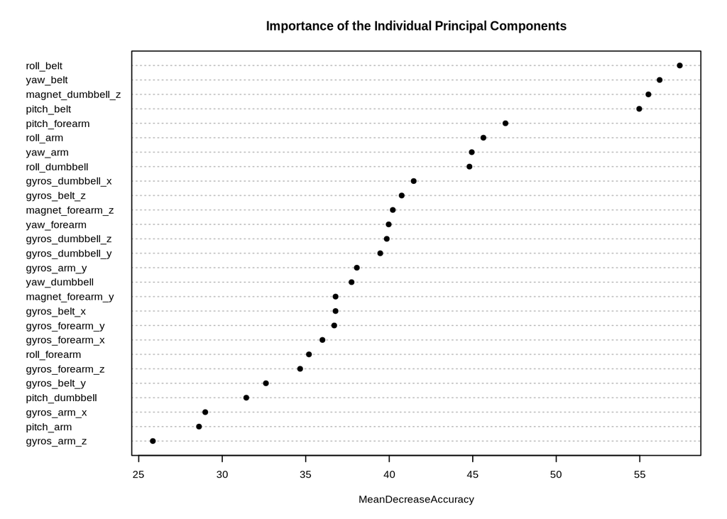

```r
varImpPlot(modelRF$finalModel, sort = TRUE, type = 1, pch = 19, col = 1, cex = 0.6, main = "Importance of the Individual Principal Components")
```

This plot shows componentes by descending importance order.

## 7. Cross validation testing

```r
predModelRF <- predict(modelRF, validation)
confus <- confusionMatrix(validation$classe, predModelRF)
confus$table
```

```
##           Reference
## Prediction    A    B    C    D    E
##          A 1392    2    0    0    1
##          B    3  945    1    0    0
##          C    0    3  849    3    0
##          D    0    0    4  800    0
##          E    0    0    1    3  897
```

Now we caculate acccuracy.

```r
accMod <- postResample(validation$classe, predModelRF)
modAcc <- accMod[[1]]
modAcc
```

```
## [1] 0.9957178
```

## 8. Applying model to test cases

```r
predictor_final <- predict(modelRF, pre_testingDataSet)
predictor_final
```

```
##  [1] B A B A A E D B A A B C B A E E A B B B
## Levels: A B C D E
```

And here are the results.